# Homework 10

Yiming Gao (NetID: yimingg2)

2017/4/16

## Exercise 1

For this question we will return to the `OJ` data from the `ISLR` package. We will again attempt to predict the `Purchase` variable. After changing `uin` to your `UIN`, use the following code to test-train split the data.

```r
library(ISLR)
library(caret)
uin = 650379994
set.seed(uin)
oj_idx = createDataPartition(OJ$Purchase, p = 0.5, list = FALSE)
oj_trn = OJ[oj_idx,]
oj_tst = OJ[-oj_idx,]
```

First we set up some helper functions.

```r
# accuracy function
accuracy <- function(actual, predicted) {
  mean(actual == predicted)
}

# extract the row with the best tuning parameters
get_best_result = function(caret_fit) {
  best_result = caret_fit$results[as.numeric(rownames(caret_fit$bestTune)), ]
  rownames(best_result) = NULL
  best_result
}
```

### (a) SVM with a linear kernel

```r
lin_grid = expand.grid(C = c(2 ^ (-5:5)))
cv_5 = trainControl(method = "cv", number = 5)

svm_lin = train(Purchase ~ ., data = oj_trn,
                method = "svmLinear",
                trControl = cv_5,
                tuneGrid = lin_grid)

svm_lin_acc = round(accuracy(oj_tst$Purchase, predict(svm_lin, oj_tst)), 4)
svm_best_lin = get_best_result(svm_lin)
```

The chosen values of `C` is 0.03125. The test accuracy is 0.8127.

### (b) SVM with a polynomial kernel

```r
svm_poly = train(Purchase ~ ., data = oj_trn,
                 method = "svmPoly",
                 trControl = cv_5)

svm_best_poly = get_best_result(svm_poly)
svm_poly_acc = round(accuracy(oj_tst$Purchase, predict(svm_poly, oj_tst)), 4)
```

```r
# confusion matrix
table(oj_tst$Purchase, predict(svm_poly, oj_tst))
```

```
##
##       CH  MM
##   CH 289  37
##   MM  60 148
```

Confusion matrix is above.

The chosen values of `degree`, `scale` and `C` are 2, 0.01 and 1. The test accuracy is 0.8184.

### (c) SVM with a radial kernel

```r
rad_grid = expand.grid(C = c(2 ^ (-2:3)), sigma  = c(2 ^ (-3:1)))

svm_rad = train(Purchase ~ ., data = oj_trn,
                method = "svmRadial",
                trControl = cv_5,
                tuneGrid = rad_grid)

svm_rad_acc = round(accuracy(oj_tst$Purchase, predict(svm_rad, oj_tst)), 4)
svm_best_rad = get_best_result(svm_rad)
```

The chosen values of `C` and `sigma` are 4 and 0.25. The test accuracy is 0.7828.

### (d) Random Forest

```r
rf_grid = expand.grid(mtry = 1: (ncol(oj_trn) - 1))

rf = train(Purchase ~ ., data = oj_trn,
           method = "rf",
           trControl = cv_5,
           tuneGrid = rf_grid)

rf_best = get_best_result(rf)
rf_acc = round(accuracy(oj_tst$Purchase, predict(rf, oj_tst)), 4)
```

The chosen values of `mtry` is 8. The test accuracy is 0.7959.

### Summarization

```r
method = c("SVM with linear kernel", "SVM with polynomial kernel", "SVM with radial kernel", "Random Forest")

tst_acc = c(svm_lin_acc, svm_poly_acc, svm_rad_acc, rf_acc)

results1 = data.frame(method, tst_acc)
colnames(results1) = c("Method", "Test Accuracy")
knitr::kable(results1, align = "c")
```

| Method | Test Accuracy |
| --- | --- |
| SVM with linear kernel | 0.8127 |
| SVM with polynomial kernel | 0.8184 |
| SVM with radial kernel | 0.7828 |
| Random Forest | 0.7959 |

From the table above, we know that **SVM with a polynomial kernel** performs best with this seed, in term of test accuracy.

## Exercise 2

For this question, use the data found in `clust_data.csv`. We will attempt to cluster this data using $k$-means. But, what $k$ should we use?

```r
clust = read.csv("clust_data.csv")
```

### (a)

Apply $k$-means to this data 15 times, using number of centers from 1 to 15. Each time use `nstart = 10` and store the `tot.withinss` value from the resulting object.

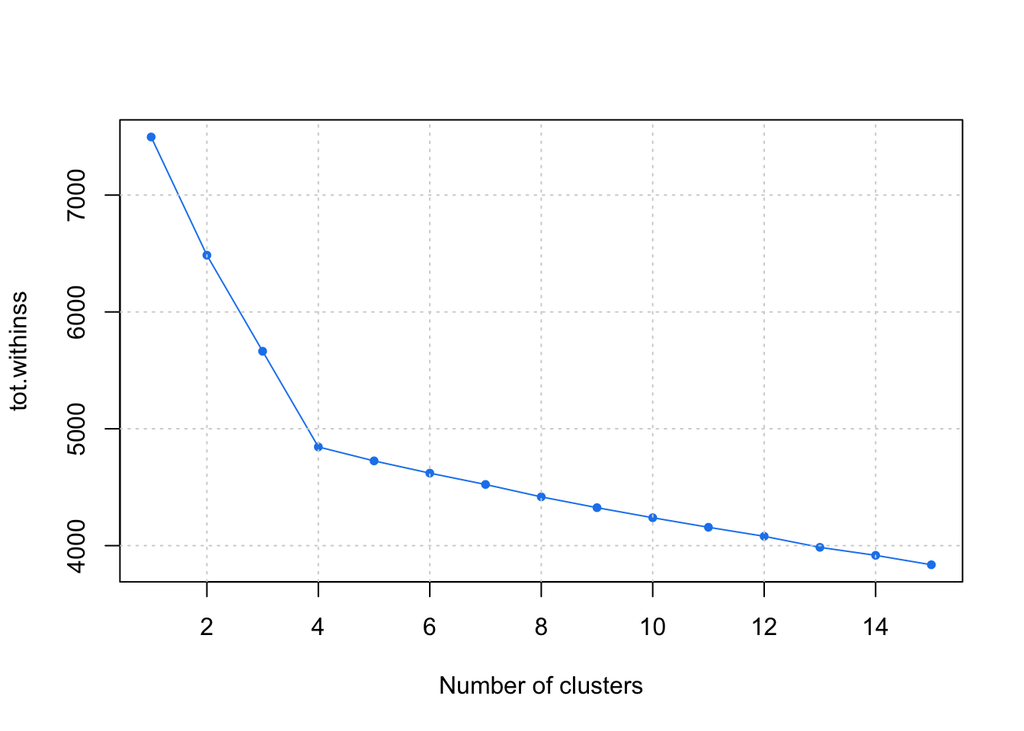

```r
tot_withinss = rep(0, 15)

for (i in 1:15) {
  kmean = kmeans(clust, centers = i, nstart = 10)
  tot_withinss[i] = kmean$tot.withinss
}

plot(1: 15, tot_withinss, pch = 20, type = "o", col = "dodgerblue2", xlab = "Number of clusters", ylab = "tot.withinss")
grid()
```

The elbow occurs at 4, we may consider keeping first 4 clusters.

### (b)

Re-apply $k$-means for your chosen number of centers. How many observations are placed in each cluster? What is the value of `tot.withinss`?

```r
kmean = kmeans(clust, centers = 4, nstart = 10)
kmean$size # 25
```

```
## [1] 25 25 25 25
```

```r
kmean$tot.withinss
```

```
## [1] 4844.926
```

25 observations are placed in each cluster. Here `tot.withinss` is 4844.9258176.

### (c)

Visualize this data. Plot the data using the first two variables and color the points according to the $k$-means clustering. Based on this plot, do you think you made a good choice for the number of centers? (Briefly explain.)

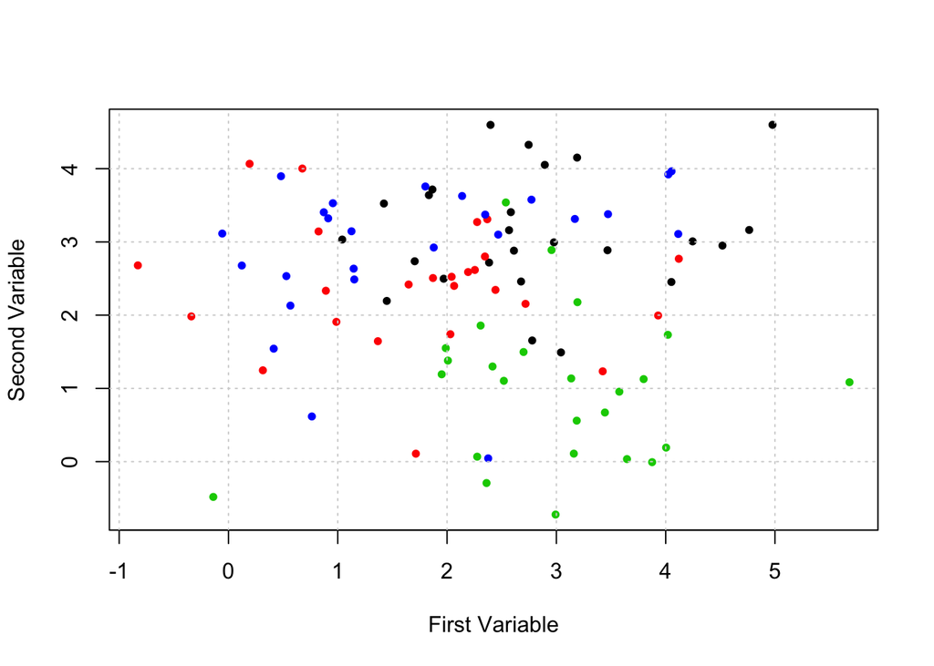

```r
kmeans_clusters = kmean$cluster

plot(
  clust[, 1],
  clust[, 2],
  col = kmeans_clusters,
  pch = 20,
  xlab = "First Variable",
  ylab = "Second Variable"
)
grid()
```

I don’t think k-means performs well in this case. Clusters are overlapped and hard to separate the points out.

### (d)

Use PCA to visualize this data. Plot the data using the first two principal components and color the points according to the $k$-means clustering. Based on this plot, do you think you made a good choice for the number of centers? (Briefly explain.)

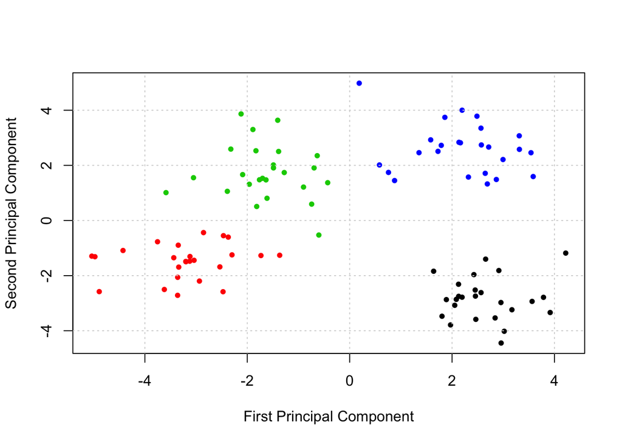

```r
clust_pca = prcomp(clust, scale = TRUE)

#summary(clust_pca)

plot(
  clust_pca$x[, 1],
  clust_pca$x[, 2],
  col = kmeans_clusters,
  pch = 20,
  xlab = "First Principal Component",
  ylab = "Second Principal Component"
)
grid()
```

The graph above clearly reverals four separated clusters, which indicates our number of clusters is appropriate.

### (e)

Calculate the proportion of variation explained by the principal components. Make a plot of the cumulative proportion explained. How many principal components are need to explain 95% of the variation in the data?

```r
# the proportion of variance explained by a pc
get_PVE = function(pca_out) {
  pca_out$sdev ^ 2 / sum(pca_out$sdev ^ 2)
}

pve = get_PVE(clust_pca)

head(pve)
```

```
## [1] 0.13856040 0.11471199 0.11266132 0.03890720 0.03360915 0.03241022
```

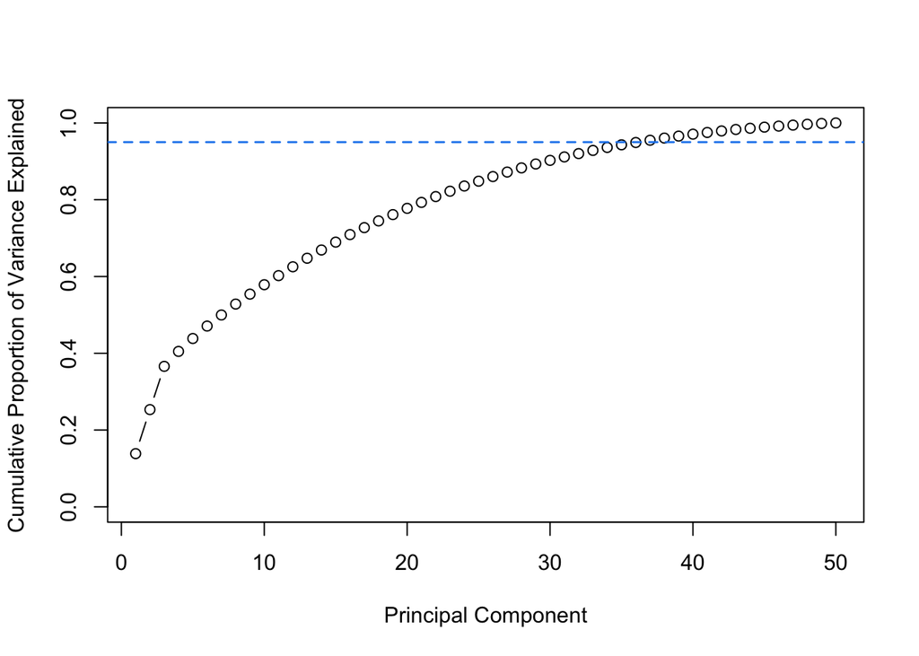

```r
plot(
  cumsum(pve),
  xlab = "Principal Component",
  ylab = "Cumulative Proportion of Variance Explained",
  ylim = c(0, 1),
  type = 'b'
)
abline(h = 0.95, lty = 2, col = "dodgerblue2", lwd = 1.5)
```

```r
min(which((cumsum(pve) >= 0.95) == TRUE))
```

```
## [1] 37
```

```r
cumsum(pve)[37]
```

```
## [1] 0.9549179
```

We need 37 principal components to achieve the goal. And 37 PCs will explain 95.49% of the variation in the data.

## Exercise 3

### (a)

Perform hierarchical clustering six times. Consider all possible combinations of linkages (average, single, complete) and data scaling. (Scaled, Unscaled.)

| Linkage | Scaling |
| --- | --- |
| Single | No |
| Average | No |
| Complete | No |
| Single | Yes |
| Average | Yes |
| Complete | Yes |

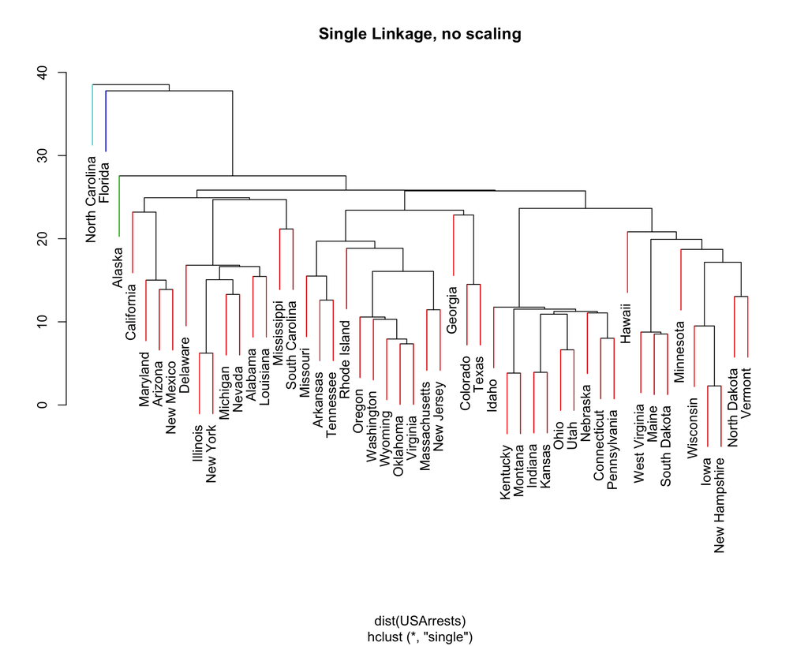

```r
# single linkage, no scaling
hc1 = hclust(dist(USArrests), method = "single")
hcut1 = cutree(hc1, 4)

ColorDendrogram(hc1, y = hcut1,
                labels = names(hcut1),
                main = "Single Linkage, no scaling",
                branchlength = 7.3)
```

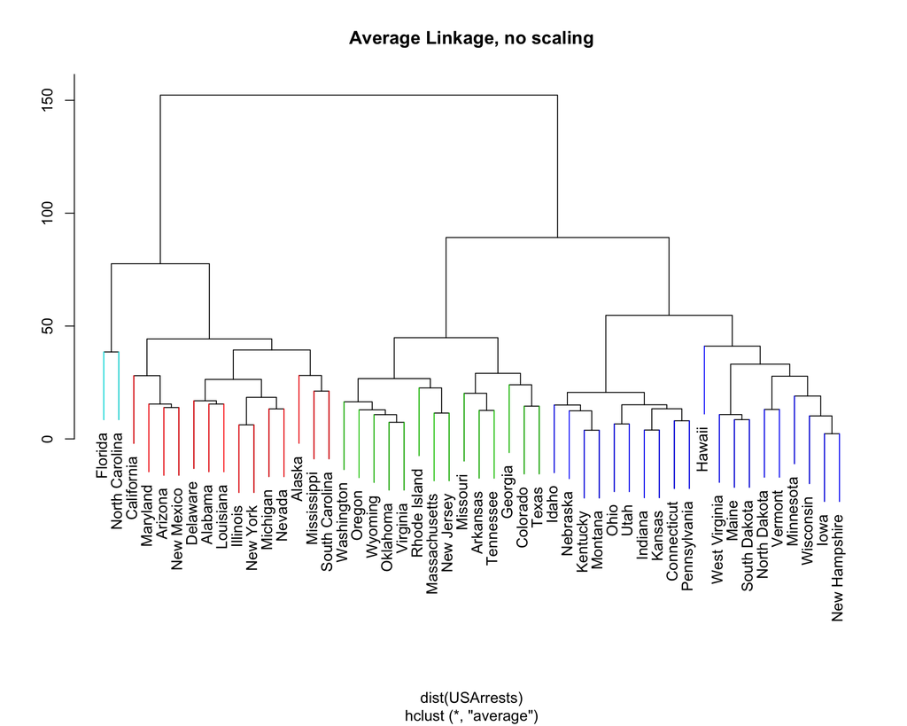

```r
# average linkage, no scaling
hc2 = hclust(dist(USArrests), method = "average")
hcut2 = cutree(hc2, 4)

ColorDendrogram(hc2, y = hcut2,
                labels = names(hcut2),
                main = "Average Linkage, no scaling",
                branchlength = 30)
```

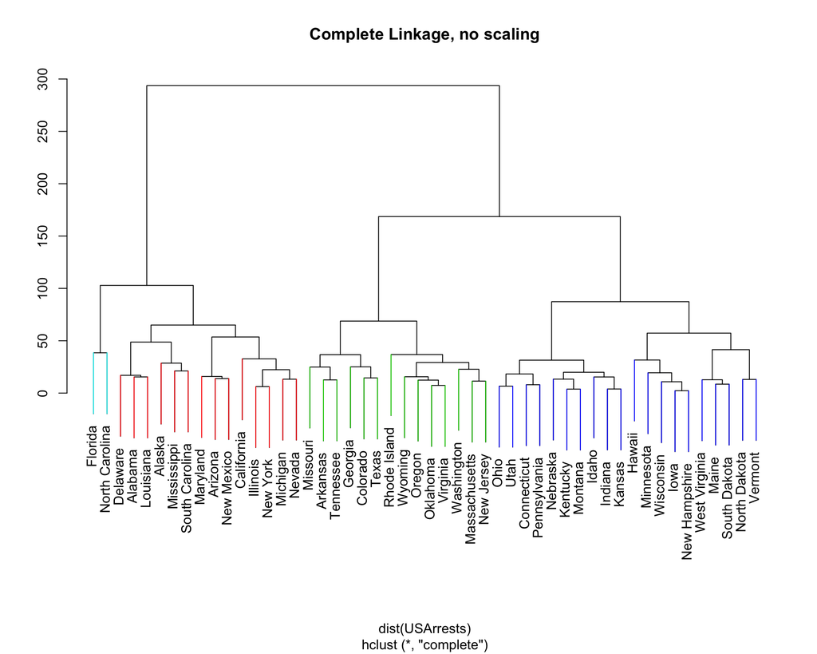

```r
# complete linkage, no scaling
hc3 = hclust(dist(USArrests), method = "complete")
hcut3 = cutree(hc3, 4)

ColorDendrogram(hc3, y = hcut3,
                labels = names(hcut3),
                main = "Complete Linkage, no scaling",
                branchlength = 58)
```

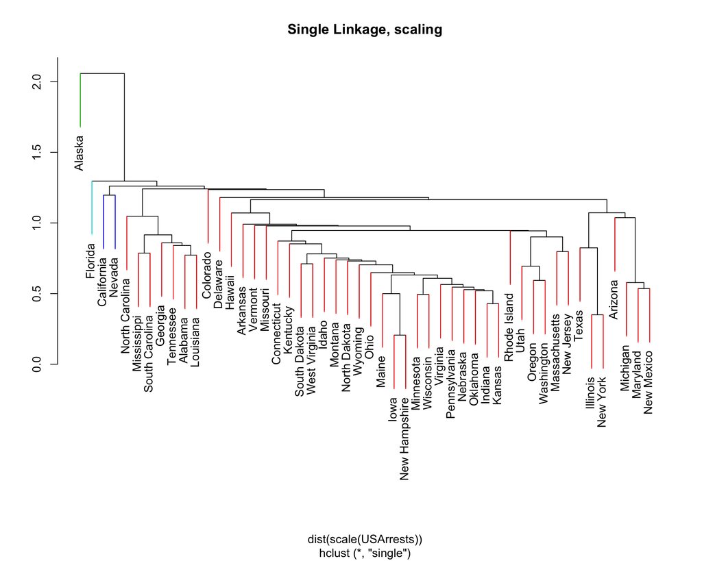

```r
# single linkage, scaling
hc4 = hclust(dist(scale(USArrests)), method = "single")
hcut4 = cutree(hc4, 4)

ColorDendrogram(hc4, y = hcut4,
                labels = names(hcut4),
                main = "Single Linkage, scaling",
                branchlength = 0.38)
```

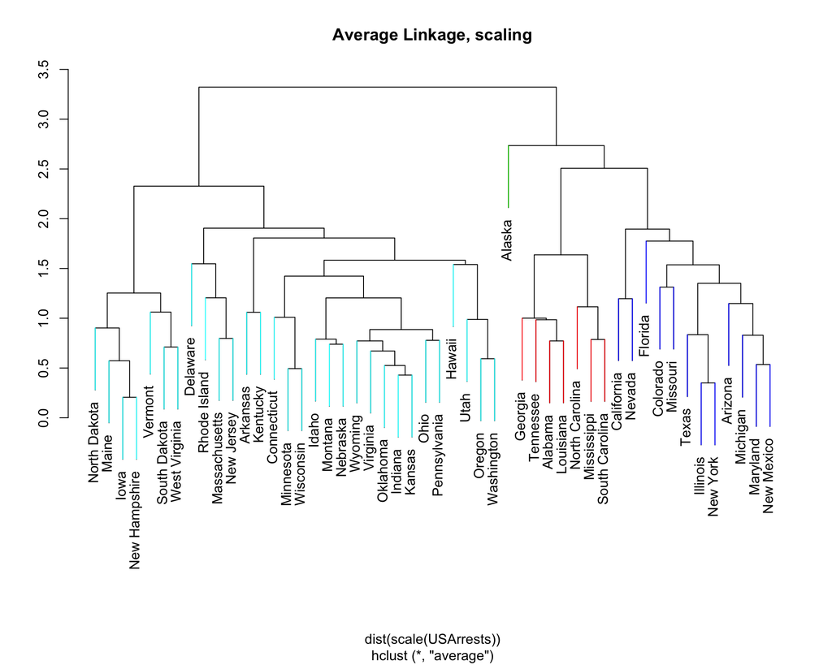

```r
# average linkage, scaling
hc5 = hclust(dist(scale(USArrests)), method = "average")
hcut5 = cutree(hc5, 4)

ColorDendrogram(hc5, y = hcut5,
                labels = names(hcut5),
                main = "Average Linkage, scaling",
                branchlength = 0.62)
```

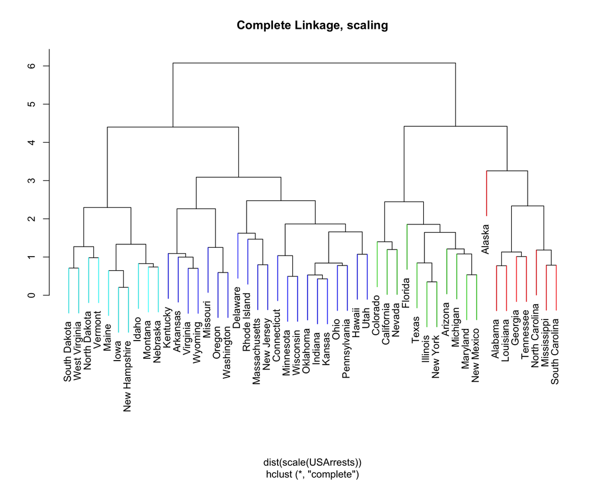

```r
# complete linkage, scaling
hc6 = hclust(dist(scale(USArrests)), method = "complete")
hcut6 = cutree(hc6, 4)

ColorDendrogram(hc6, y = hcut6,
                labels = names(hcut6),
                main = "Complete Linkage, scaling",
                branchlength = 1.18)
```

Each time, cut the dendrogram at a height that results in four distinct clusters. Plot the results, with a color for each cluster.

**(b)** Based on the above plots, do any of the results seem more useful than the others? (There is no correct answer here.) Pick your favorite. (Again, no correct answer.)

I prefer the last one, i.e., **complete linkage with scaling**. Because it has separated data evenly into four clusters as we want. However, in other plots, there seem to be at least one cluster contains too much or few records.

**(c)** Use the documentation for `?hclust` to find other possible linkages. Pick one and try it. Compare the results to your favorite from **(b)**. Is it much different?

I use `'median'` as linkage this time.

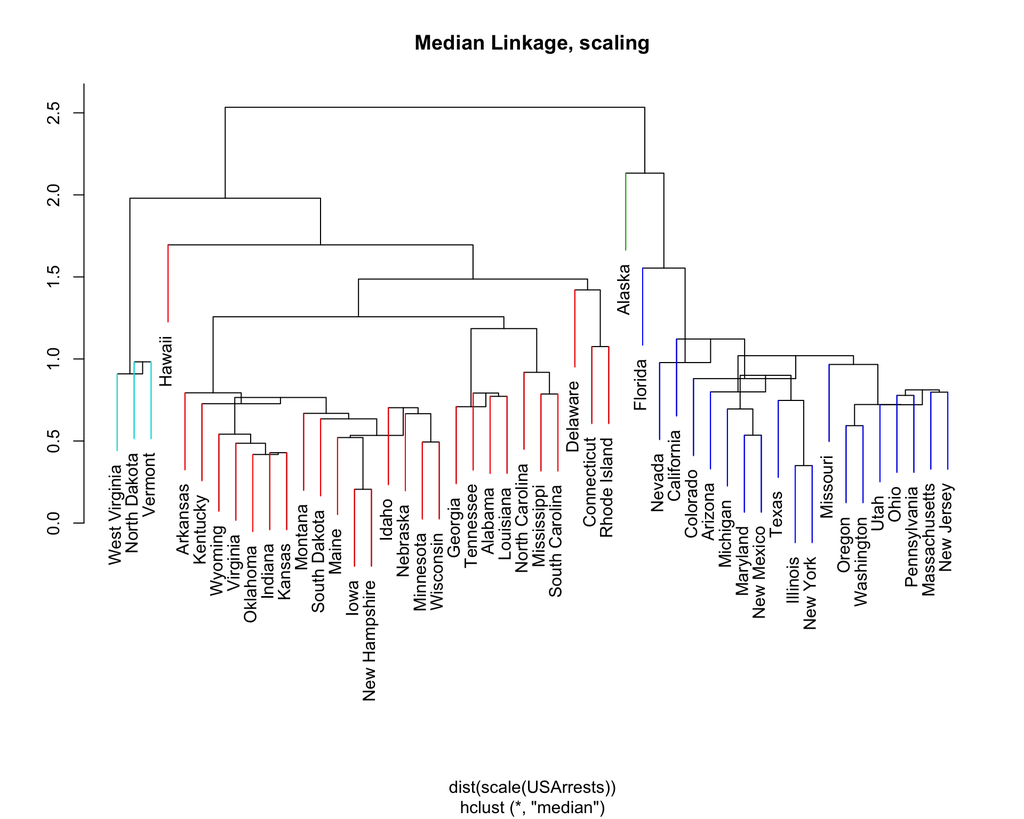

```r
hc7 = hclust(dist(scale(USArrests)), method = "median")
hcut7 = cutree(hc7, 4)

ColorDendrogram(hc7, y = hcut7,
                labels = names(hcut7),
                main = "Median Linkage, scaling",
                branchlength = 0.47)
```

We notice there are two clusters contain only three and one observations, which is very differenct from the results from (b).

**(d)** Use the documentation for `?dist` to find other possible distance measures. (We have been using `euclidean`.) Pick one (not `binary`) and try it. Compare the results to your favorite from **(b)**. Is it much different?

Here I choose `'manhattan'` as the distance measure.

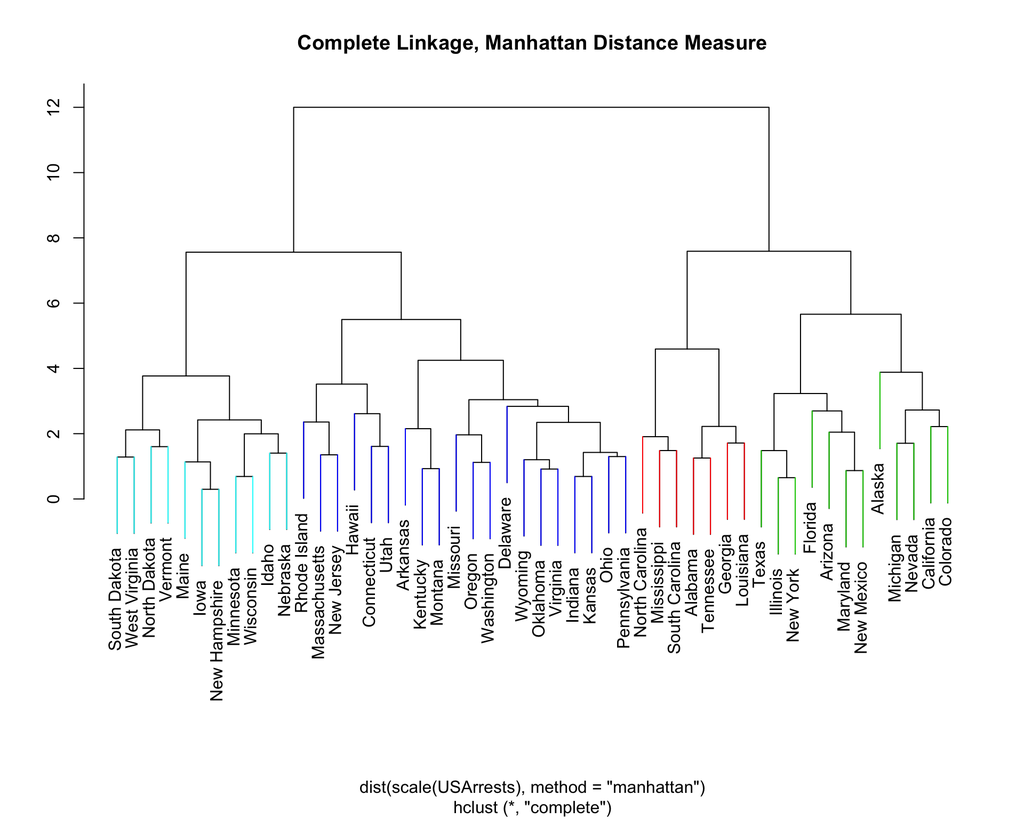

```r
# complete linkage, scaling
hc8 = hclust(dist(scale(USArrests), method = "manhattan"), method = "complete")
hcut8 = cutree(hc8, 4)

ColorDendrogram(hc8, y = hcut8,
                labels = names(hcut8),
                main = "Complete Linkage, Manhattan Distance Measure",
                branchlength = 2.33)
```

It seems that there is not much difference between this one and the results from (b). They both similarly separate out the data.